# Life History Attributes Influencing Metabolic Variation in an Estuarine Fish

E. Hoots

2026-06-12

# READ ME

All code and data analysis associated with “Life History Attributes Influencing Metabolic Variation in an Estuarine Fish” published in Functional Ecology in 2026. Authors: Hoots, Elizabeth; Kuchenmüller, Luis; Skeeles, Michael; Clark, Timothy

This analysis will explore the influence of energy allocated to growth on the baseline metabolism (standard metabolic rate or SMR) of juvenile fish. SMR is usually measured on fasted, postprandial, resting individuals, although in theoretical best practice it is also measured on a non-reproductive adult individual (no energy allocated to growth or maturation). In this study, I aim to study the relative influence of both growth and reproductive development on the baseline metabolism of *Galaxias maculatus*.

# CONTACT

Elizabeth C. Hoots

Email: ehoots.research@gmail.com

GitHub: https://github.com/E-Hoots-Research

Web: https://elizabeth-hoots.owlstown.net/

# LOAD REQUIRED PACKAGES

```r
# installs and loads packages, need to install "pacman" first

pacman::p_load("brms",
               "broom",
               "broom.mixed",
               "car",
               "coda",
               "cowplot",
               "dplyr",
               "emmeans",
               "ggeffects",
               "ggiraphExtra",
               "ggplot2",
               "ggpubr",
               "grid",
               "hms",
               "lme4",
               "lmerTest",
               "lsmeans",
               "lubridate",
               "multcomp",
               "multcompView",
               "nlme",
               "posterior",
               "purrr",
               "readxl",
               "rsq",
               "tidyr",
               "wesanderson"
)
```

# Read in data from Hoots et al. (2026) - hereafter “B1”

```r
ds <- read.csv("001_Raw_Data/DS1_Hoots2026.csv") # read in data table

month_order <- c("April", "May", "June", "July", "August", "September", "November", "March") # assign chronological order to Month (otherwise alphabetical)
ds$Month <- factor(ds$Month, levels = month_order) # assign month_order to factor variable "Month" in ds

ds1 <- ds %>%
  arrange(ID_fish, Month) %>%
  group_by(ID_fish) %>%
  mutate(mass_prev = lag(mass))

#month_order <- c("May", "June", "July", "August", "September", "November", "March") # assign chronological order to Month (otherwise alphabetical)
ds1$Month <- factor(ds1$Month, levels = month_order) # assign month_order to factor variable "Month" in ds1

ds1 <- ds1 %>%
  arrange(ID_fish, Month) %>%
  group_by(ID_fish) %>%
  mutate(SMR_prev = lag(SMR),
         MMR_prev = lag(MMR)) %>%
    ungroup()


ds1 <- ds1 %>%
  dplyr::mutate(
    Date = as.Date(time_start, format = "%d/%m/%Y")
  ) %>%
  dplyr::mutate(ds = "B1",
                ID = paste("B1",ID_fish, sep = "_"),
                Temp = as.factor(Temp_class),
                SMR_mass = NA,
                SMR_mass_prev = NA,
                MMR_mass = NA,
                MMR_mass_prev = NA) %>%
  dplyr::mutate(Temp = case_when(
    Temp == 18 ~ "18a",
    Temp == 23 ~ as.factor(23),
    .default = Temp
  )) %>%
  dplyr::select(ds, Month, Date, Temp, ID, mass, mass_prev, SGR, SMR, SMR_mass, SMR_resid, SMR_prev, SMR_mass_prev, MMR, MMR_mass, MMR_prev, MMR_mass_prev)
```

For this dataset, I also want to make an extra SGR calculation that spans a 2-month interval. This will allow me to make a comparison between “centred” SGR and metabolism later on.

```r
ds1 <- ds1 %>%
  group_by(ID) %>%
  mutate(SGR_2m = (log(mass) - lag(log(mass), n = 2)) / as.numeric(difftime(Date, lag(Date, n = 2), units = "days")) * 100) %>%
  ungroup()

ds1 <- ds1[which(ds1$Month != "April"),] # subset a new table which excludes April, use if temp treatment matters or if not SGR
```

We are also interested in merging in some data on maturation in these fish, represented by the ratio between their gut and body cavity depth

```r
#### let's also quickly take a look at those gut ratios
B1_gut <- read.csv("001_Raw_Data/GutRatio.csv")

# Ensure Temp is correctly assigned
B1_gut <- B1_gut %>%
  mutate(
    Ratio = 100*Ratio,
    Rack = as.factor(Rack),
    Date = as.Date(Date, format = "%d/%m/%Y"),
    Julian = as.numeric(format(Date, "%j")),  # Convert Date to Julian day
    stage = as.factor(stage),
    ID = as.character(ID_fish),
    ID_fish = NULL,
    Temp = as.factor(case_when(Rack == 1 ~ as.factor("18a"), Rack == 3 ~ as.factor(23)))
  ) %>%
  mutate(ID = paste0("B1_", ID))
```

[figure not shown]

### Gut ratio by individual across two measurements in August

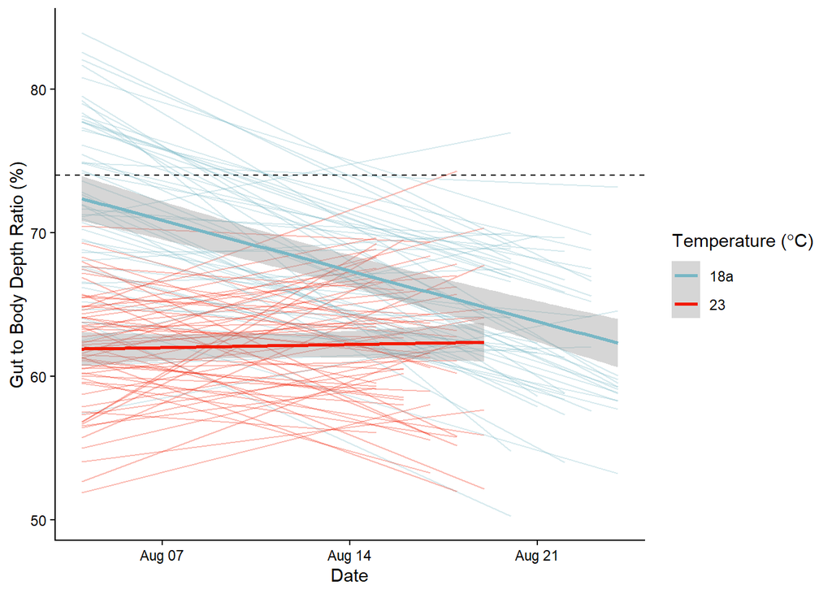

```r
ggplot(data=B1_gut, aes(x = Date, y = Ratio, color = Temp)) +
  geom_hline(yintercept = 74, linetype = "dashed", color = "black") +
  geom_line(aes(group = ID), alpha = 0.3) +
  geom_smooth(aes(group = Temp), method = "lm") +
  theme_bw() +
  scale_color_manual(values = c("#78B7C5", "#F21A00")) +
  labs(color = expression("Temperature ("*degree*C*")"), y = "Gut to Body Depth Ratio (%)") +
  theme_classic()
```

This figure shows that fish at 23C generally did not mature in August, nor do they seem to have matured in July like the 18C fish did. It would be useful for the 18C fish to have a paired measurement of July SMR with gut ratio, which would help us understand whether a relationship exists between energy allocated to maturation and SMR.

### Extrapolating measurements of gut ratio to correspond with July SMR measurements for 18C treatment fish only, as 23C fish were not found to have matured.

To start, let’s generate a simple linear model to show (over)predicted gut ratio values as a comparison for some extrapolated quadratic model values:

```r
# Define July dates
July <- ds1 %>%
  filter(Temp == "18a") %>%
  filter(Month == "July") %>%
  dplyr::select("Date", "Temp", "ID")

# Fit individual regressions only for fish with at least two data points
gut_models <- B1_gut %>%
  group_by(ID) %>%
  filter(n() > 1) %>%  # Ensure at least two data points per fish
  summarise(
    model = list(lm(Ratio ~ Date, data = pick(everything())))
  ) %>%
  ungroup()

# Predict values for July
gut_predictions <- July %>%
  left_join(gut_models, by = "ID") %>%
  mutate(
    Ratio = map2_dbl(model, Date, ~ if (!is.null(.x)) predict(.x, newdata = data.frame(Date = .y)) else NA_real_)
    ) %>%
  dplyr::select(ID, Date, Temp, Ratio)

# Combine with original data
B1_gut_linear <- bind_rows(
  B1_gut %>% dplyr::select(ID, Date, Temp, Ratio),
  gut_predictions
) %>% rename(
  Ratio_linear = Ratio
)

B1_gut_linear$ID <- as.character(B1_gut_linear$ID)

# Merge extrapolated data into ds1
ds1 <- ds1 %>%
  left_join(B1_gut_linear %>% dplyr::select("ID", "Date", "Ratio_linear"), by = c("ID", "Date"), na_matches = "na")
```

Let’s visualize that now:

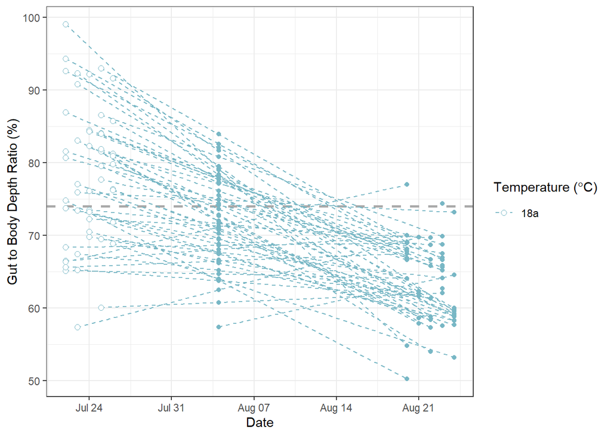

```r
fig_line <- ggplot(B1_gut_linear[which(B1_gut_linear$"Temp" == "18a"),], aes(x = Date, y = Ratio_linear, color = Temp)) +
  geom_hline(yintercept = 74, color = "darkgrey", linewidth = 1, linetype = "dashed") +
  geom_smooth(aes(group = ID), method = "lm", linewidth = 0.5, linetype = "dashed", se = FALSE) +
  geom_point(data = B1_gut_linear[which(B1_gut_linear$Temp == "18a"),], aes(x = Date, y = Ratio_linear, color = Temp), size = 1.5) +
  geom_point(data = gut_predictions[which(gut_predictions$Temp == "18a"),], aes(x = Date, y = Ratio), size = 2, shape = 21, fill = "white") +
  scale_color_manual(values = c("#78B7C5")) +
  labs(color = expression("Temperature ("*degree*C*")"), y = "Gut to Body Depth Ratio (%)") +
  theme_bw()

fig_line
```

Now we can get a bit fancier, and try using a more biologically accurate quadratic model:

```r
# # # Fit global poly2 model (for trend)
global_model <- lm(Ratio ~ poly(Julian, 2), data = B1_gut)

# Get residuals (how each ID deviates from the trend)
B1_gut <- B1_gut %>%
  mutate(Residual = Ratio - predict(global_model, newdata = data.frame(Julian = Julian)))

# Extract individual July dates per fish - only in the 18C treatment
July_dates <- ds1 %>%
  filter(Temp == "18a") %>%
  filter(Month == "July") %>%
  dplyr::select("Date", "Temp", "ID") %>%
  mutate(
    Julian = as.numeric(format(Date, "%j")),
    Global_Pred = predict(global_model, newdata = data.frame(Julian = Julian)),  # Global trend
    ID = as.character(ID))

# Adjust for individual residuals based on their own July date
gut_predictions <- B1_gut %>%
  filter(Temp == "18a") %>%
  group_by(ID) %>%
  summarise(Mean_Residual = mean(Residual, na.rm = TRUE), Temp = first(Temp)) %>%
  ungroup() %>%
  left_join(July_dates, by = c("ID", "Temp")) %>%
  mutate(
    Ratio = Global_Pred + Mean_Residual  # Adjusted extrapolation for each fish's date
  ) %>%
  dplyr::select(ID, Date, Julian, Temp, Ratio)

# Combine observed data & adjusted extrapolated points
B1_gut_extrap <- bind_rows(
  B1_gut %>% mutate(ID = as.character(ID)) %>% dplyr::select(ID, Date, Temp, Ratio),
  gut_predictions
) %>%
  mutate(Julian = as.numeric(format(Date, "%j")))

B1_gut_extrap$ID <- as.character(B1_gut_extrap$ID)

# Merge extrapolated data into ds1
ds1 <- ds1 %>%
  left_join(B1_gut_extrap %>% dplyr::select("ID", "Date", "Ratio"), by = c("ID", "Date"), na_matches = "na")
```

Let’s visualize that:

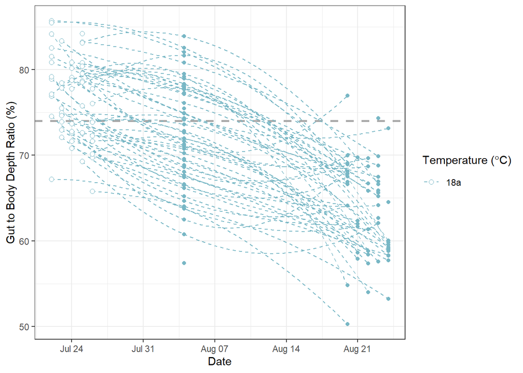

We have now extrapolated individual-level estimates for gut-to-body-depth ratio at the July respirometry trial dates, using each fish’s residuals from a global 2nd-order polynomial model. This follows the relationship found in Skeeles et al. (2023), as well as the timing of maturation and re-absorption of reproductive tissues - although this seems to have occurred on an accelerated timeline in these fish compared to Skeeles et al. (2023). These values do not differ greatly from what was seen using linear models to extrapolate, however the linear model predicted biologically unlikely gut ratio values near 100%, while this model does not.

```r
# merge extrapolated data into ds1
ds1 <- ds1 %>%
  left_join(B1_gut_extrap %>% dplyr::select("ID", "Date", "Ratio"), by = c("ID", "Date"), na_matches = "na") %>%
  left_join(B1_gut_linear %>% dplyr::select("ID", "Date", "Ratio_linear"), by = c("ID", "Date"), na_matches = "na") %>%
  mutate(Date = NULL,
         SGR_2m = lead(SGR_2m),
         Ratio = Ratio.x,
         Ratio_linear = Ratio_linear.x,
         Ratio.y = NULL,
         Ratio_linear.y = NULL,
         log_SMR = log10(SMR),
         log_MMR = log10(MMR),
         log_mass = log10(mass)) %>%
  dplyr::select(ds, Month, Temp, ID, mass, mass_prev, SGR, SGR_2m, SMR, SMR_mass, SMR_resid, SMR_prev, SMR_mass_prev, MMR, MMR_mass, MMR_prev, MMR_mass_prev, Ratio, Ratio_linear, log_SMR, log_MMR, log_mass)
```

# read in data from Hoots et al., 2024 - hereafter “B2”

```r
ds2 <- read.csv("001_Raw_Data/DS2_Hoots2024.csv")

#Note: SGR for November is calculated as % mass increase per day, from September to December (functionally centered). SGR for March is calculated from December to March, and thus is not centered or suitable for this analysis.

ds2<- ds2 %>%
  dplyr::mutate(
    ds = "B2",
    Month = as.factor(Month),
    Temp = as.factor("18b"), #as.factor(Temp)
    mass_prev = NA,
    SGR_2m = as.numeric(case_when(Month == "November" ~ SGR, Month == "March" ~ NA)) ,
    ID = paste("B2",ID, sep = "_"),
    mass_SMR = SMR_mass,
    SMR_resid = NA,
    SMR_mass = NA,
    SMR_mass_prev = NA,
    MMR_mass = NA,
    MMR_mass_prev = NA,
    log_SMR = log10(SMR),
    log_MMR = log10(MMR),
    log_mass = log10(mass),
    Ratio = NA,
    Ratio_linear = NA
  ) %>%
  arrange(ID, Month) %>%
  group_by(ID) %>%
  mutate(mass_prev = lag(mass)) %>%
  ungroup() %>%
  dplyr::select(ds, Month, Temp, ID, mass, mass_prev, SGR, SGR_2m, SMR, SMR_mass, SMR_resid, SMR_prev, SMR_mass_prev, MMR, MMR_mass, MMR_prev, MMR_mass_prev, Ratio, Ratio_linear, log_SMR, log_MMR, log_mass)
```

# read in data from Skeeles et al., 2023 - hereafter “M”

```r
ds3 <- read_excel("001_Raw_data/DS3_Skeeles2024.xlsx", sheet = "Beth Normoxia Only")

ds3 <- ds3 %>%
  dplyr::mutate(
    ds = "M",
    Month = "June",
    Temp = as.factor(temperature),
    ID = as.character(paste0("M", row_number())),
    #ID = paste("M", id, sep = "_"),
    mass = `average of 1st and 2nd mass (g)`,
    mass_prev = NA,
    SGR = NA,
    SGR_2m = NA,
    SMR = SMRnorm,
    SMR_mass = NA,
    SMR_resid = NA,
    SMR_prev = NA,
    SMR_mass_prev = NA,
    MMR = MMRnorm,
    MMR_mass = NA,
    MMR_prev = NA,
    MMR_mass_prev = NA,
    Ratio = `gutwidth/totalwidth`,
    Ratio_linear = `gutwidth/totalwidth`,
    log_SMR = log10(SMRnorm),
    log_MMR = log10(MMRnorm),
    log_mass = log10(`average of 1st and 2nd mass (g)`)
  ) %>%
  arrange(ID, Month) %>%
  group_by(ID) %>%
  mutate(mass_prev = lag(mass)) %>%
  ungroup() %>%
 dplyr::select(ds, Month, Temp, ID, mass, mass_prev, SGR, SGR_2m, SMR, SMR_mass, SMR_resid, SMR_prev, SMR_mass_prev, MMR, MMR_mass, MMR_prev, MMR_mass_prev, Ratio, Ratio_linear, log_SMR, log_MMR, log_mass)
```

# merge 3 datasets into single master table

```r
data <- bind_rows(ds1, ds2, ds3)

temp_order <- c(15, "18a", "18b", 20, 23) # assign chronological order to Temp (otherwise alphabetical)
data$Temp <- factor(data$Temp, levels = temp_order) # assign temp_order to factor variable "Temp" in ds1
data$Month <- factor(data$Month, levels = month_order) # assign month_order to factor variable "Month" in ds1


# summarise data for Functional Ecology replication statement:

# Count repeated measures per fish (this gives replication information for metabolism and mass)
fish_repeats <- data %>% #subset data by !is.na(SGR_2m) or !is.na(Ratio) for factor-specific replication information
  group_by(ID) %>%
  summarise(
    n_measurements = n(),   # counts rows per fish
    .groups = "drop"
  )

# Summarise across fish: mean ± SD of repeated measurements
summary_repeats <- fish_repeats %>%
  summarise(
    mean_reps = mean(n_measurements),
    sd_reps   = sd(n_measurements),
    min_reps  = min(n_measurements),
    max_reps  = max(n_measurements),
    n_fish    = n()
  )

# View results
fish_repeats      # table of counts per fish
```

```
## # A tibble: 199 × 2
##    ID     n_measurements
##    <chr>           <int>
##  1 B1_1                5
##  2 B1_10               5
##  3 B1_100              5
##  4 B1_102              5
##  5 B1_103              5
##  6 B1_104              1
##  7 B1_105              5
##  8 B1_106              5
##  9 B1_107              5
## 10 B1_108              5
## # ℹ 189 more rows
```

```r
summary_repeats   # mean ± SD across fish
```

```
## # A tibble: 1 × 5
##   mean_reps sd_reps min_reps max_reps n_fish
##       <dbl>   <dbl>    <int>    <int>  <int>
## 1      3.62    1.69        1        5    199
```

```r
#and by temperature treatment:

# Count repeated measures per fish within each Temp
fish_repeats_by_temp <- data %>%
  group_by(ds, Temp, ID) %>%
  summarise(
    n_measurements = n(),
    .groups = "drop"
  )

# Summarise across fish within each Temp
summary_repeats_by_temp <- fish_repeats_by_temp %>%
  group_by(ds) %>%
  summarise(
    n_fish     = n(),                        # number of unique fish
    mean_reps  = mean(n_measurements),       # mean repeats per fish
    sd_reps    = sd(n_measurements),         # SD of repeats per fish
    min_reps   = min(n_measurements),
    max_reps   = max(n_measurements),
    .groups = "drop"
  )

# View results
fish_repeats_by_temp     # counts per fish by temperature
```

```
## # A tibble: 199 × 4
##    ds    Temp  ID    n_measurements
##    <chr> <fct> <chr>          <int>
##  1 B1    18a   B1_1               5
##  2 B1    18a   B1_10              5
##  3 B1    18a   B1_11              5
##  4 B1    18a   B1_12              5
##  5 B1    18a   B1_13              5
##  6 B1    18a   B1_14              5
##  7 B1    18a   B1_15              5
##  8 B1    18a   B1_16              5
##  9 B1    18a   B1_17              5
## 10 B1    18a   B1_18              5
## # ℹ 189 more rows
```

```r
summary_repeats_by_temp  # summary per temperature
```

```
## # A tibble: 3 × 6
##   ds    n_fish mean_reps sd_reps min_reps max_reps
##   <chr>  <int>     <dbl>   <dbl>    <int>    <int>
## 1 B1       137      4.57   1.05         1        5
## 2 B2        34      1.94   0.239        1        2
## 3 M         28      1      0            1        1
```

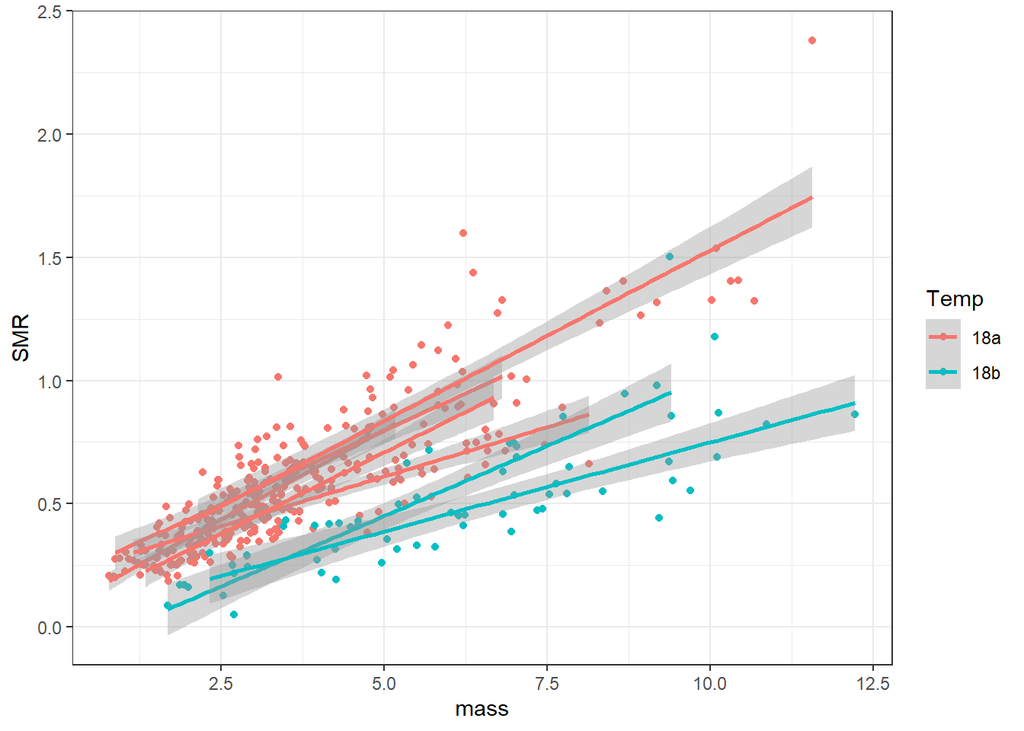

```r
# MMR methods comparison
ggplot(data = data[which(data$Temp == "18a" | data$Temp == "18b"),], aes(x = mass, y = SMR)) +
  geom_point(aes(color = Temp)) +
  geom_smooth(method = "lm", aes(group = Month, color = Temp)) +
  theme_bw()
```

```r
#write.csv(data, "ch3_mergeddata.csv")
```

# mass-standardize all SMR to grand mean mass

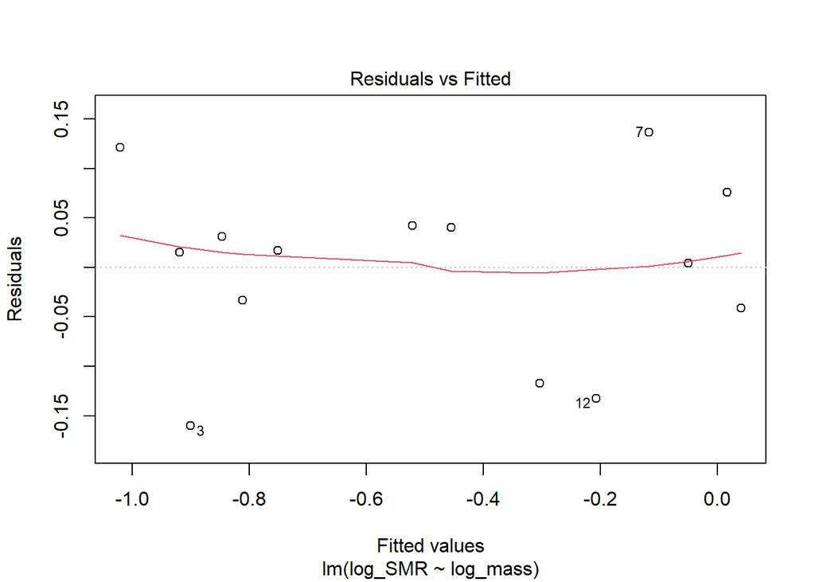

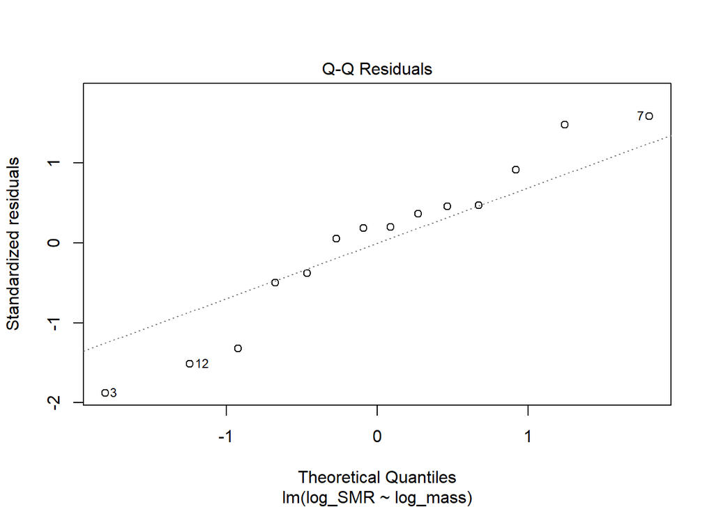

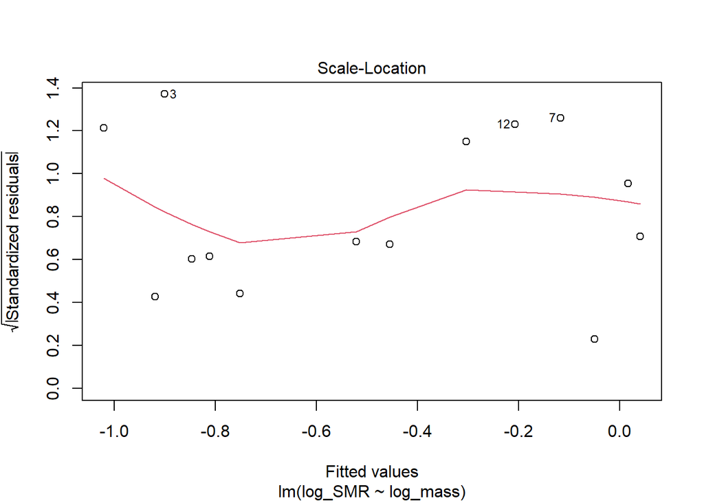

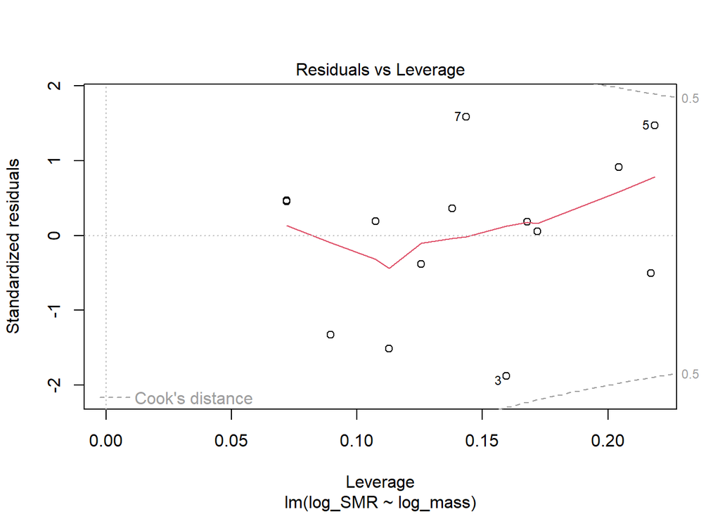

```r
#test also with merged 18C

lm_15_SMR <- lm(log_SMR ~ log_mass, data = data[which(data$Temp == 15),])
plot(lm_15_SMR)
```

```r
summary(lm_15_SMR)
```

```
##
## Call:
## lm(formula = log_SMR ~ log_mass, data = data[which(data$Temp ==
##     15), ])
##
## Residuals:
##      Min       1Q   Median       3Q      Max
## -0.16035 -0.03914  0.01628  0.04166  0.13653
##
## Coefficients:
##             Estimate Std. Error t value Pr(>|t|)
## (Intercept) -0.99308    0.04198  -23.66 1.95e-11 ***
## log_mass     1.04697    0.07024   14.90 4.18e-09 ***
## ---
## Signif. codes:  0 '***' 0.001 '**' 0.01 '*' 0.05 '.' 0.1 ' ' 1
##
## Residual standard error: 0.09305 on 12 degrees of freedom
## Multiple R-squared:  0.9488, Adjusted R-squared:  0.9445
## F-statistic: 222.2 on 1 and 12 DF,  p-value: 4.18e-09
```

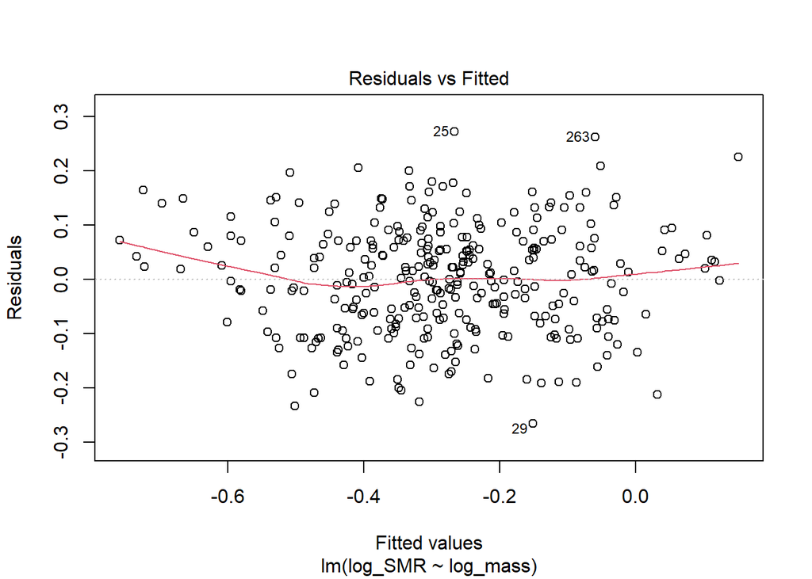

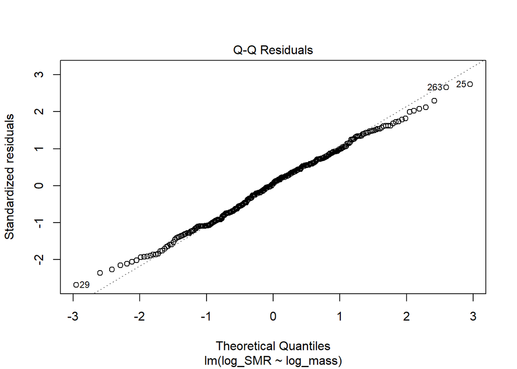

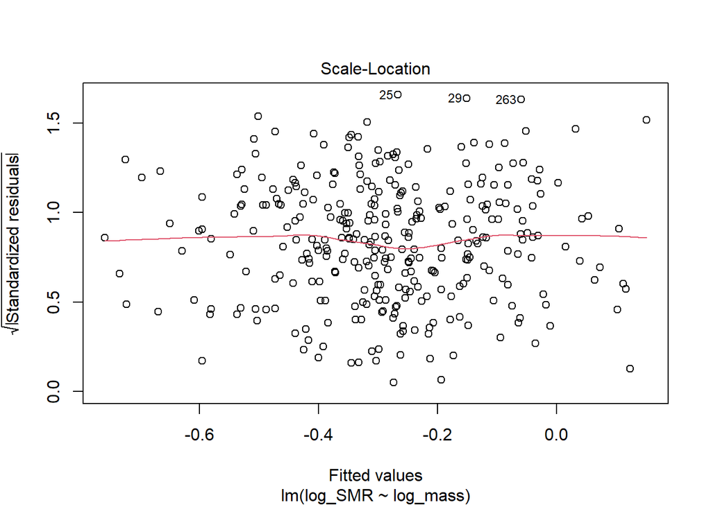

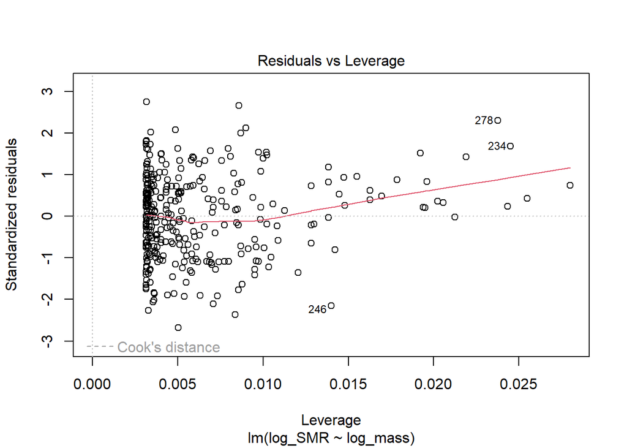

```r
lm_18a_SMR <- lm(log_SMR ~ log_mass, data = data[which(data$Temp == "18a"),])
plot(lm_18a_SMR)
```

```r
summary(lm_18a_SMR)
```

```
##
## Call:
## lm(formula = log_SMR ~ log_mass, data = data[which(data$Temp ==
##     "18a"), ])
##
## Residuals:
##       Min        1Q    Median        3Q       Max
## -0.265938 -0.073035  0.004946  0.071003  0.272393
##
## Coefficients:
##             Estimate Std. Error t value Pr(>|t|)
## (Intercept) -0.67905    0.01417  -47.91   <2e-16 ***
## log_mass     0.78038    0.02567   30.40   <2e-16 ***
## ---
## Signif. codes:  0 '***' 0.001 '**' 0.01 '*' 0.05 '.' 0.1 ' ' 1
##
## Residual standard error: 0.09935 on 317 degrees of freedom
## Multiple R-squared:  0.7446, Adjusted R-squared:  0.7438
## F-statistic:   924 on 1 and 317 DF,  p-value: < 2.2e-16
```

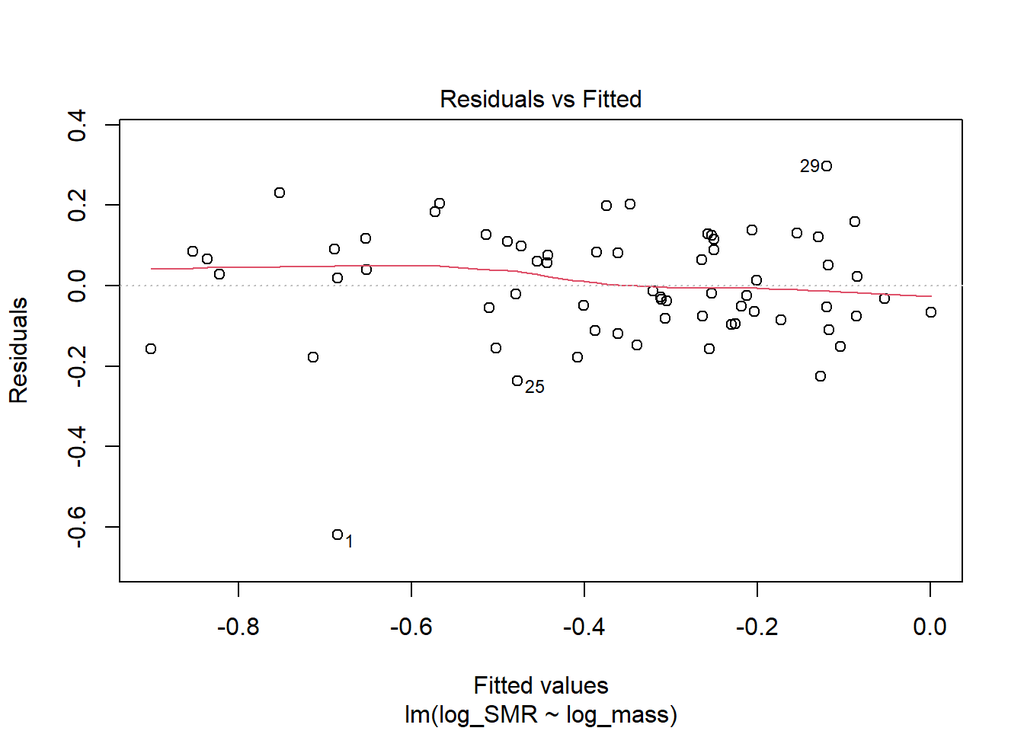

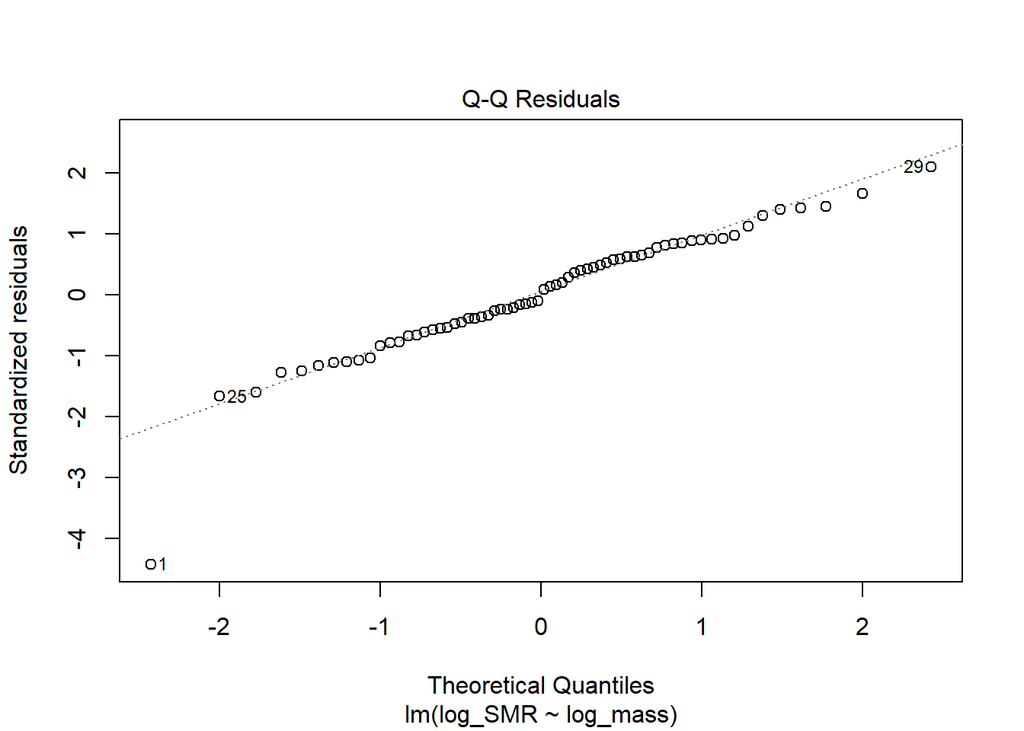

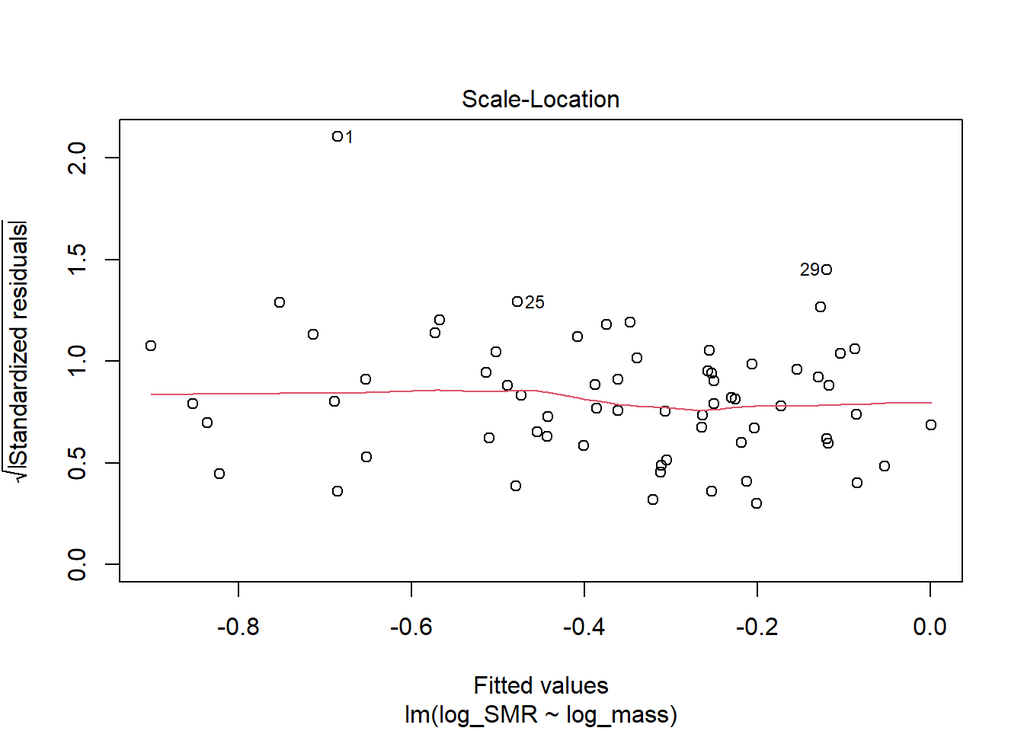

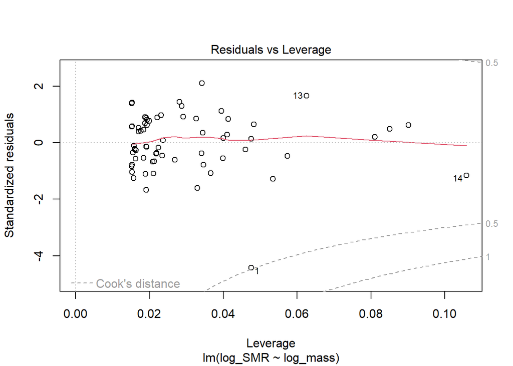

```r
lm_18b_SMR <- lm(log_SMR ~ log_mass, data = data[which(data$Temp == "18b"),])
plot(lm_18b_SMR)
```

```r
summary(lm_18b_SMR)
```

```
##
## Call:
## lm(formula = log_SMR ~ log_mass, data = data[which(data$Temp ==
##     "18b"), ])
##
## Residuals:
##      Min       1Q   Median       3Q      Max
## -0.62016 -0.08006 -0.00085  0.09614  0.29682
##
## Coefficients:
##             Estimate Std. Error t value Pr(>|t|)
## (Intercept) -1.13729    0.06466  -17.59   <2e-16 ***
## log_mass     1.04673    0.08436   12.41   <2e-16 ***
## ---
## Signif. codes:  0 '***' 0.001 '**' 0.01 '*' 0.05 '.' 0.1 ' ' 1
##
## Residual standard error: 0.1434 on 64 degrees of freedom
## Multiple R-squared:  0.7064, Adjusted R-squared:  0.7018
## F-statistic:   154 on 1 and 64 DF,  p-value: < 2.2e-16
```

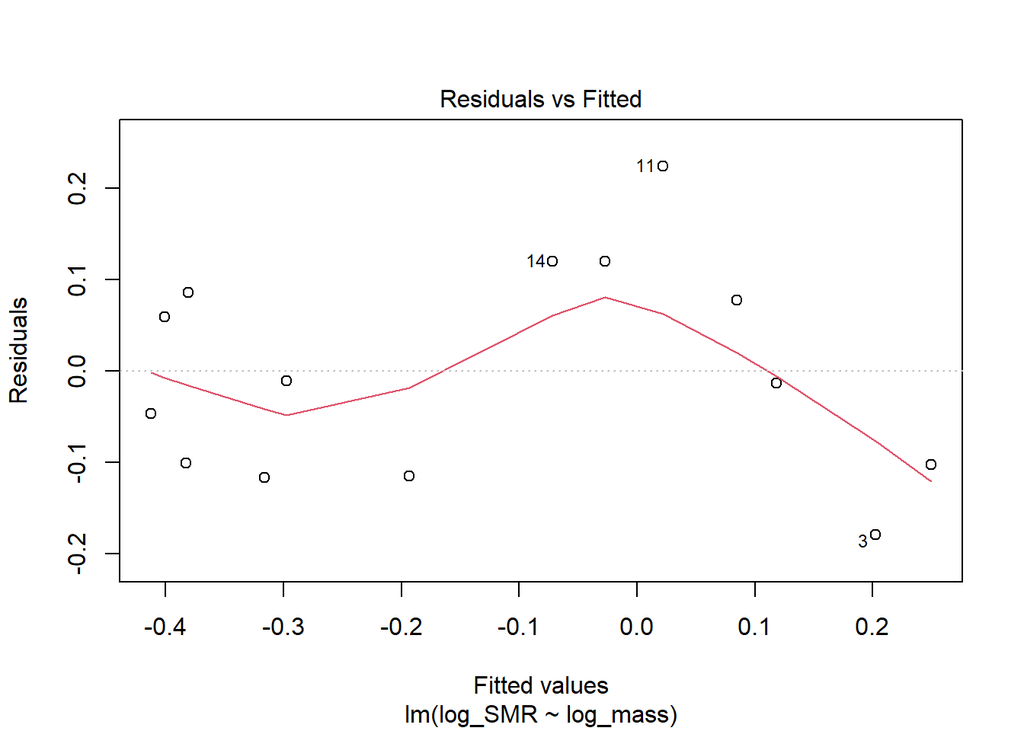

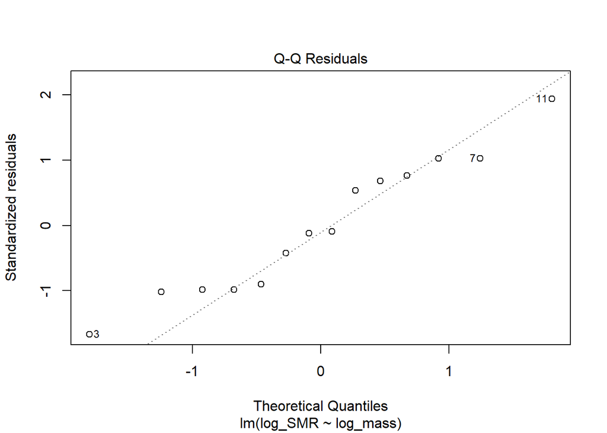

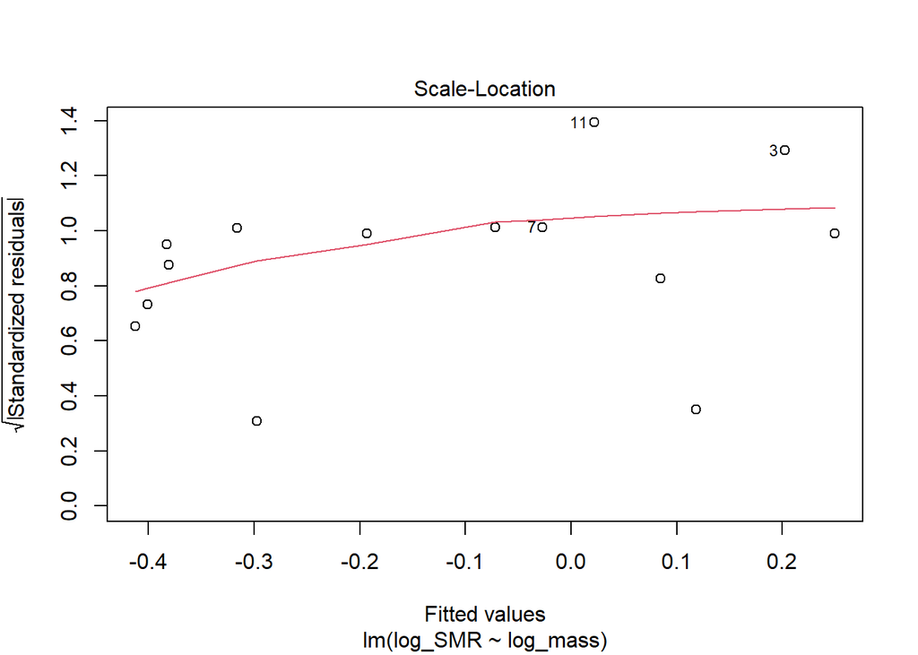

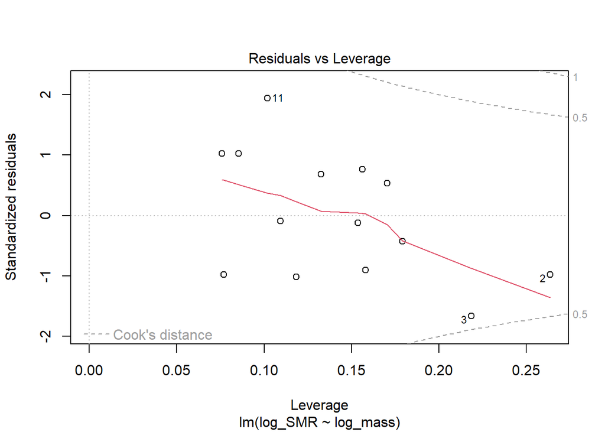

```r
#lm_18_SMR <- lm(log_SMR ~ log_mass, data = data[which(data$Temp == "18b" | data$Temp == "18a"),])
#plot(lm_18_SMR)
#summary(lm_18_SMR)

lm_20_SMR <- lm(log_SMR ~ log_mass, data = data[which(data$Temp == 20),])
plot(lm_20_SMR)
```

```r
summary(lm_20_SMR)
```

```
##
## Call:
## lm(formula = log_SMR ~ log_mass, data = data[which(data$Temp ==
##     20), ])
##
## Residuals:
##      Min       1Q   Median       3Q      Max
## -0.17948 -0.10213 -0.01224  0.08365  0.22381
##
## Coefficients:
##             Estimate Std. Error t value Pr(>|t|)
## (Intercept) -0.63589    0.07844  -8.107 3.28e-06 ***
## log_mass     0.76964    0.10839   7.101 1.25e-05 ***
## ---
## Signif. codes:  0 '***' 0.001 '**' 0.01 '*' 0.05 '.' 0.1 ' ' 1
##
## Residual standard error: 0.1217 on 12 degrees of freedom
## Multiple R-squared:  0.8078, Adjusted R-squared:  0.7917
## F-statistic: 50.42 on 1 and 12 DF,  p-value: 1.246e-05
```

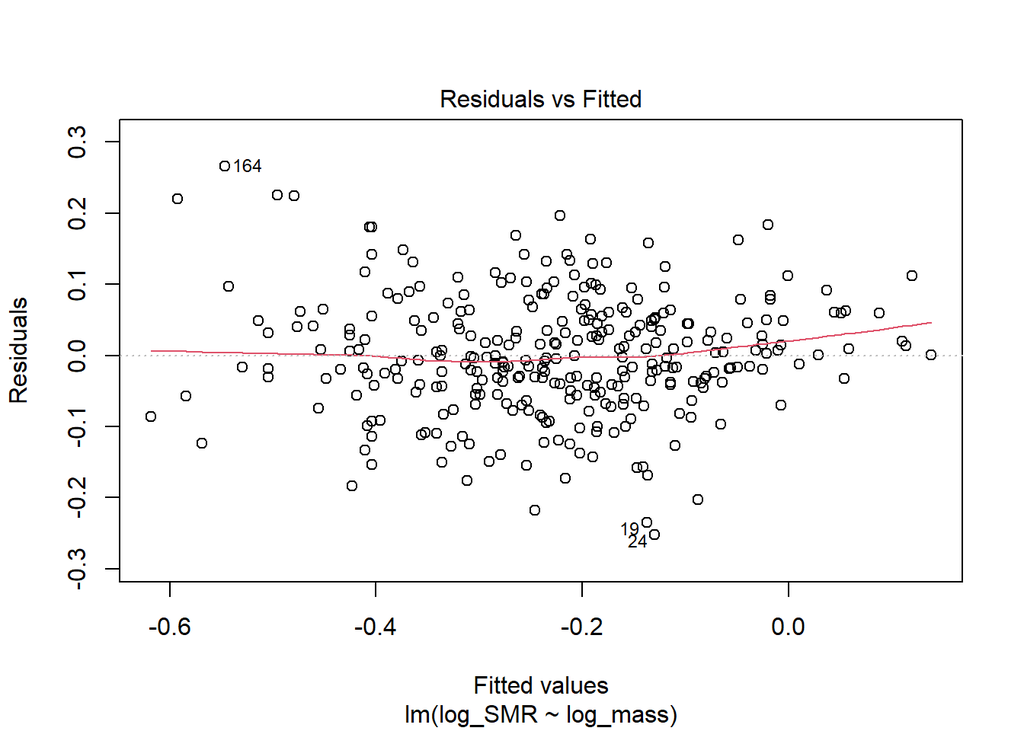

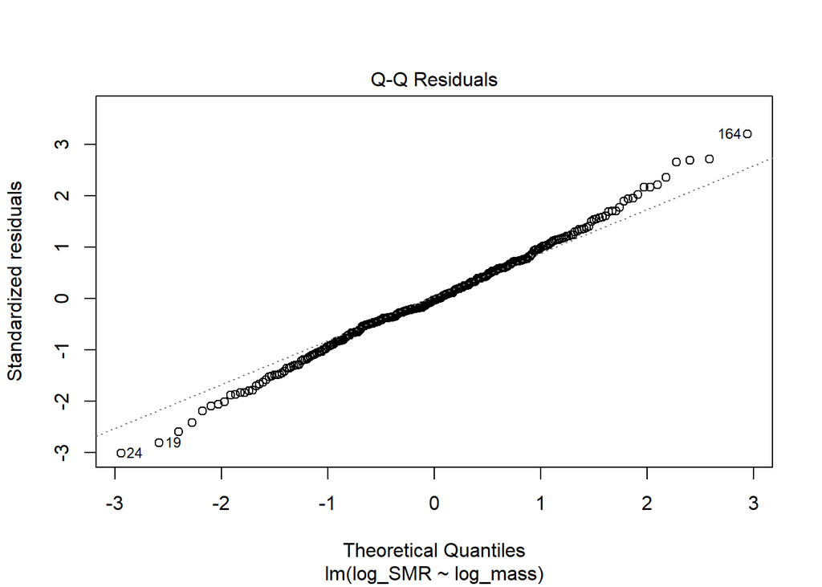

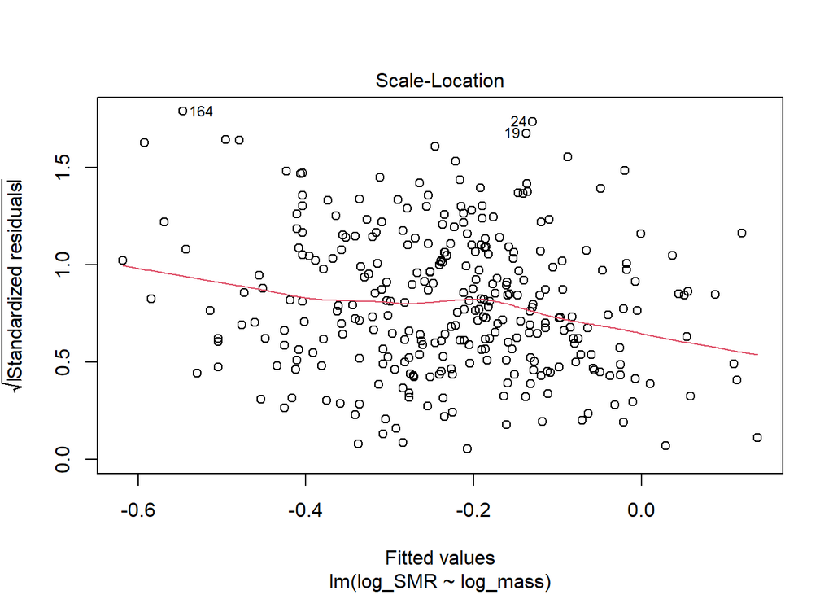

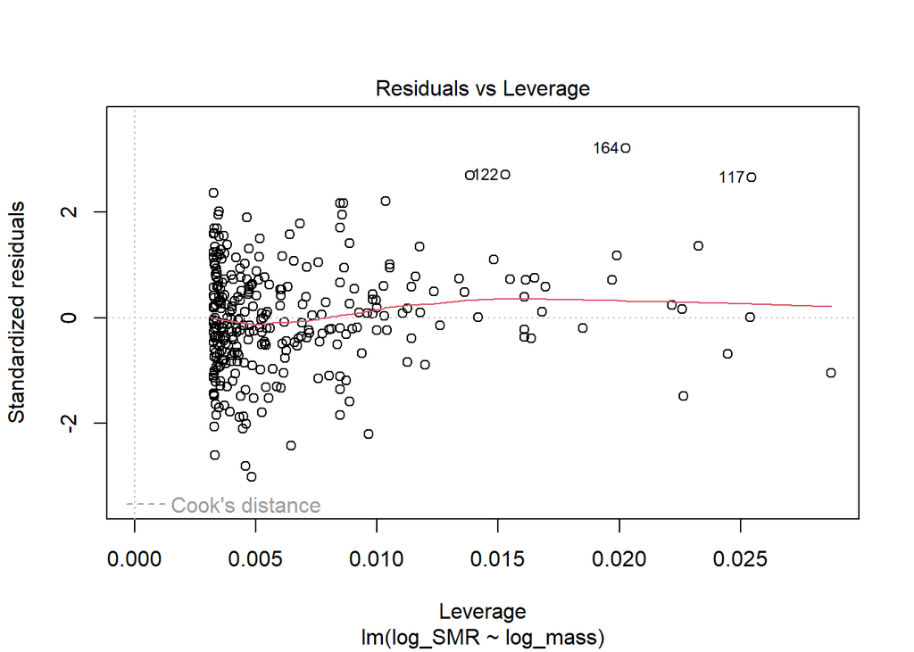

```r
lm_23_SMR <- lm(log_SMR ~ log_mass, data = data[which(data$Temp == 23),])
plot(lm_23_SMR)
```

```r
summary(lm_23_SMR)
```

```
##
## Call:
## lm(formula = log_SMR ~ log_mass, data = data[which(data$Temp ==
##     23), ])
##
## Residuals:
##       Min        1Q    Median        3Q       Max
## -0.252455 -0.045555 -0.003137  0.050623  0.265964
##
## Coefficients:
##              Estimate Std. Error t value Pr(>|t|)
## (Intercept) -0.473811   0.009711  -48.79   <2e-16 ***
## log_mass     0.611061   0.020900   29.24   <2e-16 ***
## ---
## Signif. codes:  0 '***' 0.001 '**' 0.01 '*' 0.05 '.' 0.1 ' ' 1
##
## Residual standard error: 0.08391 on 305 degrees of freedom
## Multiple R-squared:  0.737,  Adjusted R-squared:  0.7362
## F-statistic: 854.8 on 1 and 305 DF,  p-value: < 2.2e-16
```

```r
log_mass_grandmean = data.frame(log_mass = log10(mean(data$mass))) #grand mean mass is 3.47 g

SMR_mean_predicted_15 = predict(lm_15_SMR, newdata = log_mass_grandmean)
SMR_mean_predicted_18a = predict(lm_18a_SMR, newdata = log_mass_grandmean)
SMR_mean_predicted_18b = predict(lm_18b_SMR, newdata = log_mass_grandmean)
#SMR_mean_predicted_18 = predict(lm_18_SMR, newdata = log_mass_grandmean)
SMR_mean_predicted_20 = predict(lm_20_SMR, newdata = log_mass_grandmean)
SMR_mean_predicted_23 = predict(lm_23_SMR, newdata = log_mass_grandmean)

data <- data %>% mutate(resid = NA)

#adding the residuals calculated from our regressions to our table
data[which(data$Temp == 15),] <- data[which(data$Temp == 15),] %>%
  mutate(resid = residuals(lm_15_SMR))

data[which(data$Temp == "18a"),] <- data[which(data$Temp == "18a"),] %>%
  mutate(resid = residuals(lm_18a_SMR))

data[which(data$Temp == "18b"),] <- data[which(data$Temp == "18b"),] %>%
  mutate(resid = residuals(lm_18b_SMR))

#data[which(data$Temp == "18a" | data$Temp == "18b"),] <- data[which(data$Temp == "18a" | data$Temp == "18b"),] %>%
# mutate(resid = residuals(lm_18_SMR))

data[which(data$Temp == 20),] <- data[which(data$Temp == 20),] %>%
  mutate(resid = residuals(lm_20_SMR))

data[which(data$Temp == 23),] <- data[which(data$Temp == 23),] %>%
  mutate(resid = residuals(lm_23_SMR))


data$log_SMR_mass[data$Temp == 15] <-
  SMR_mean_predicted_15 + data$resid[data$Temp == 15]

data$log_SMR_mass[data$Temp == "18a"] <-
  SMR_mean_predicted_18a + data$resid[data$Temp == "18a"]

data$log_SMR_mass[data$Temp == "18b"] <-
  SMR_mean_predicted_18b + data$resid[data$Temp == "18b"]

#data$log_SMR_mass[data$Temp == "18a" | data$Temp == "18b"] <-
# SMR_mean_predicted_18 + data$resid[data$Temp == "18a" | data$Temp == "18b"]

data$log_SMR_mass[data$Temp == 20] <-
  SMR_mean_predicted_20 + data$resid[data$Temp == 20]

data$log_SMR_mass[data$Temp == 23] <-
  SMR_mean_predicted_23 + data$resid[data$Temp == 23]


data <- data %>%
  mutate(
    SMR_mass = as.numeric(10^log_SMR_mass)
  ) %>%
  dplyr::select( -log_SMR_mass, -log_SMR, -resid)  # Clean up unnecessary columns

data <- data %>%
  arrange(ID, Month) %>%
  group_by(ID) %>%
  mutate(SMR_mass_prev = lag(SMR_mass)) %>%
  ungroup()

cor(data$SMR_mass, data$mass, use = "complete.obs")
```

```
## [1] -0.2618141
```

```r
#write.csv(data, file = "ch3datamerge.csv", col.names = TRUE, row.names = FALSE)
```

# mass-standardize all MMR to grand mean mass

```r
data$ID <- as.factor(data$ID)

lm_15 <- lm(log_MMR ~ log_mass, data = data[which(data$Temp == 15),])
lm_18a <- lm(log_MMR ~ log_mass, data = data[which(data$Temp == "18a"),])
lm_18b <- lm(log_MMR ~ log_mass, data = data[which(data$Temp == "18b"),])
lm_20 <- lm(log_MMR ~ log_mass, data = data[which(data$Temp == 20),])
lm_23 <- lm(log_MMR ~ log_mass, data = data[which(data$Temp == 23),])

#test with merged 18C

MMR_mean_predicted_15 = predict(lm_15, newdata = log_mass_grandmean)
MMR_mean_predicted_18a = predict(lm_18a, newdata = log_mass_grandmean)
MMR_mean_predicted_18b = predict(lm_18b, newdata = log_mass_grandmean)
MMR_mean_predicted_20 = predict(lm_20, newdata = log_mass_grandmean)
MMR_mean_predicted_23 = predict(lm_23, newdata = log_mass_grandmean)

data <- data %>% mutate(resid = NA)

#adding the residuals calculated from our regressions to our table
data[which(data$Temp == 15),] <- data[which(data$Temp == 15),] %>%
  mutate(resid = residuals(lm_15))

data[which(data$Temp == "18a"),] <- data[which(data$Temp == "18a"),] %>%
  mutate(resid = residuals(lm_18a))

data[which(data$Temp == "18b"),] <- data[which(data$Temp == "18b"),] %>%
  mutate(resid = residuals(lm_18b))

data[which(data$Temp == 20),] <- data[which(data$Temp == 20),] %>%
  mutate(resid = residuals(lm_20))

data[which(data$Temp == 23),] <- data[which(data$Temp == 23),] %>%
  mutate(resid = residuals(lm_23))

data <- data %>% mutate(log_MMR_mass = NA)

data$log_MMR_mass[data$Temp == 15] <-
  MMR_mean_predicted_15 + data$resid[data$Temp == 15]

data$log_MMR_mass[data$Temp == "18a"] <-
  MMR_mean_predicted_18a + data$resid[data$Temp == "18a"]

data$log_MMR_mass[data$Temp == "18b"] <-
  MMR_mean_predicted_18b + data$resid[data$Temp == "18b"]

data$log_MMR_mass[data$Temp == 20] <-
  MMR_mean_predicted_20 + data$resid[data$Temp == 20]

data$log_MMR_mass[data$Temp == 23] <-
  MMR_mean_predicted_23 + data$resid[data$Temp == 23]


data <- data %>%
  mutate(
    MMR_mass = as.numeric(10^log_MMR_mass)
  ) %>%
  dplyr::select( -log_MMR_mass, -log_MMR, -resid)  # Clean up unnecessary columns

data <- data %>%
  arrange(ID, Month) %>%
  group_by(ID) %>%
  mutate(MMR_mass_prev = lag(MMR_mass)) %>%
  ungroup()

cor(data$MMR_mass, data$mass, use="complete.obs")
```

```
## [1] -0.1831219
```

```r
#addressing a reviewer question about the scale of within-individual variability in SMR and MMR
data_factor <- data %>%
  group_by(ID) %>%
  filter(n() > 1) %>%
  summarise(
    factor_SMR = max(SMR_mass) / min(SMR_mass),
    range_SMR = max(SMR_mass) - min(SMR_mass),
    factor_MMR = max(MMR_mass) / min(MMR_mass),
    range_MMR = max(MMR_mass) - min(MMR_mass),
    .groups = "drop"
  )
```

# data analysis

#### Mass scaling of metabolic traits across temperatures

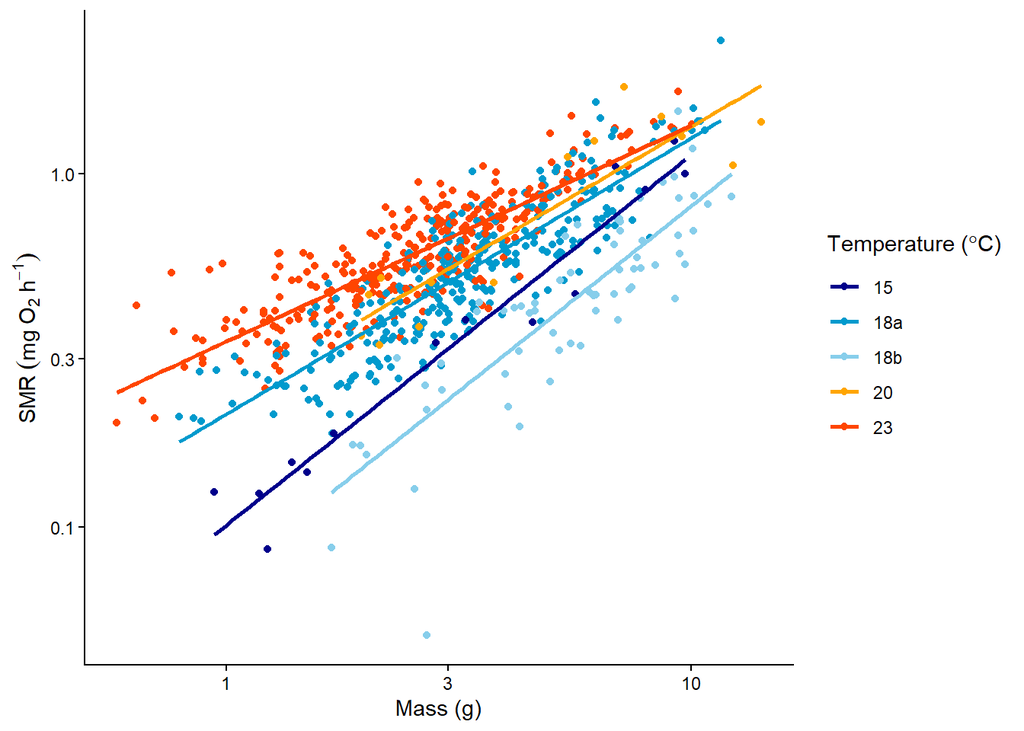

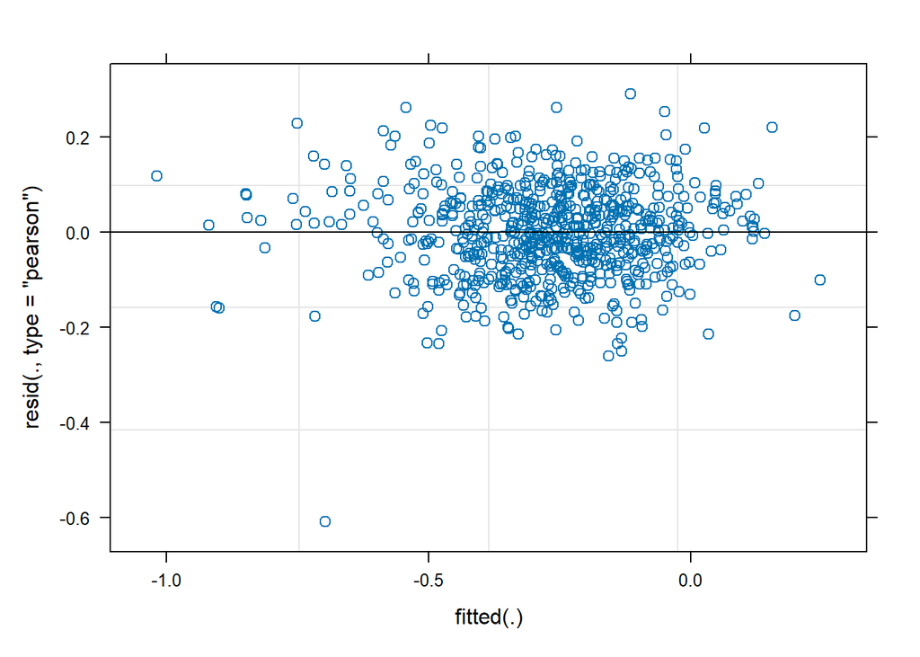

```
## Linear mixed model fit by REML. t-tests use Satterthwaite's method [
## lmerModLmerTest]
## Formula: log10(SMR) ~ log_mass * factor(Temp) + (1 | ID)
##    Data: data
##
## REML criterion at convergence: -1249.9
##
## Scaled residuals:
##     Min      1Q  Median      3Q     Max
## -6.2539 -0.6402 -0.0119  0.6281  2.9947
##
## Random effects:
##  Groups   Name        Variance  Std.Dev.
##  ID       (Intercept) 0.0002132 0.01460
##  Residual             0.0094738 0.09733
## Number of obs: 720, groups:  ID, 199
##
## Fixed effects:
##                            Estimate Std. Error         df t value Pr(>|t|)
## (Intercept)               -0.993079   0.044398 707.898837 -22.368  < 2e-16 ***
## log_mass                   1.046971   0.074298 707.898837  14.091  < 2e-16 ***
## factor(Temp)18a            0.313527   0.046643 695.930131   6.722 3.74e-11 ***
## factor(Temp)18b           -0.143021   0.063029 656.864833  -2.269 0.023583 *
## factor(Temp)20             0.357190   0.077439 707.898837   4.613 4.72e-06 ***
## factor(Temp)23             0.519722   0.045912 695.656307  11.320  < 2e-16 ***
## log_mass:factor(Temp)18a  -0.265274   0.078663 696.052964  -3.372 0.000787 ***
## log_mass:factor(Temp)18b  -0.001841   0.094473 675.872449  -0.019 0.984460
## log_mass:factor(Temp)20   -0.277327   0.114919 707.898837  -2.413 0.016064 *
## log_mass:factor(Temp)23   -0.437035   0.078408 690.387555  -5.574 3.58e-08 ***
## ---
## Signif. codes:  0 '***' 0.001 '**' 0.01 '*' 0.05 '.' 0.1 ' ' 1
##
## Correlation of Fixed Effects:
##                     (Intr) lg_mss factr(Tmp)18 fctr(Tmp)18b f(T)20 f(T)23
## log_mass            -0.806
## factr(Tmp)18        -0.952  0.767
## fctr(Tmp)18b        -0.704  0.567  0.671
## fctr(Tmp)20         -0.573  0.462  0.546        0.404
## fctr(Tmp)23         -0.967  0.779  0.920        0.681        0.554
## log_mss:fctr(Tmp)18  0.761 -0.945 -0.817       -0.536       -0.436 -0.736
## lg_mss:fctr(Tmp)18b  0.634 -0.786 -0.603       -0.868       -0.363 -0.613
## lg_ms:(T)20          0.521 -0.647 -0.496       -0.367       -0.867 -0.504
## lg_ms:(T)23          0.763 -0.948 -0.727       -0.538       -0.438 -0.809
##                     log_mss:fctr(Tmp)18 lg_mss:fctr(Tmp)18b l_:(T)20
## log_mass
## factr(Tmp)18
## fctr(Tmp)18b
## fctr(Tmp)20
## fctr(Tmp)23
## log_mss:fctr(Tmp)18
## lg_mss:fctr(Tmp)18b  0.743
## lg_ms:(T)20          0.611               0.508
## lg_ms:(T)23          0.895               0.745               0.613
```

```
##  Temp log_mass.trend     SE  df lower.CL upper.CL .group
##  23            0.610 0.0252 322    0.560    0.659  1
##  20            0.770 0.0877 708    0.598    0.942  123
##  18a           0.782 0.0260 430    0.731    0.833   2
##  18b           1.045 0.0584 582    0.930    1.160    3
##  15            1.047 0.0743 708    0.901    1.193    3
##
## Degrees-of-freedom method: kenward-roger
## Confidence level used: 0.95
## P value adjustment: tukey method for comparing a family of 5 estimates
## significance level used: alpha = 0.05
## NOTE: If two or more means share the same grouping symbol,
##       then we cannot show them to be different.
##       But we also did not show them to be the same.
```

```
##  Temp emmean      SE  df lower.CL upper.CL .group
##  18b  -0.555 0.01620 548   -0.586   -0.523  1
##  15   -0.411 0.02690 708   -0.463   -0.358   2
##  18a  -0.245 0.00587 143   -0.256   -0.233    3
##  20   -0.208 0.02780 708   -0.262   -0.153    34
##  23   -0.134 0.00700 159   -0.148   -0.120     4
##
## Degrees-of-freedom method: kenward-roger
## Results are given on the log10 (not the response) scale.
## Confidence level used: 0.95
## P value adjustment: tukey method for comparing a family of 5 estimates
## significance level used: alpha = 0.05
## NOTE: If two or more means share the same grouping symbol,
##       then we cannot show them to be different.
##       But we also did not show them to be the same.
```

```
##   Temp     emmean          SE       df   lower.CL   upper.CL .group pwr_emmean
## 3  18b -0.5545877 0.016173501 548.2511 -0.5863574 -0.5228181   1     0.2788767
## 1   15 -0.4105422 0.026888448 708.1585 -0.4633328 -0.3577516    2    0.3885598
## 2  18a -0.2446142 0.005873494 143.3781 -0.2562240 -0.2330044     3   0.5693585
## 4   20 -0.2076579 0.027788080 708.1585 -0.2622148 -0.1531010     34  0.6199292
## 5   23 -0.1339874 0.007001223 159.2230 -0.1478146 -0.1201601      4  0.7345353
##   pwr_lower pwr_upper
## 3 0.2592046 0.3000419
## 1 0.3440862 0.4387816
## 2 0.5543397 0.5847842
## 4 0.5467455 0.7029088
## 5 0.7115172 0.7582980
```

We see a narrowing-in when we plot SMR vs. mass for our four temperatures. While mass-scaling intercepts tend to increase with temperature, slopes seem to decrease. This creates an effect where, for the largest fish, there is not a visible difference in SMR by temperature treatment - they have converged to what may be a mass-imposed metabolic floor.

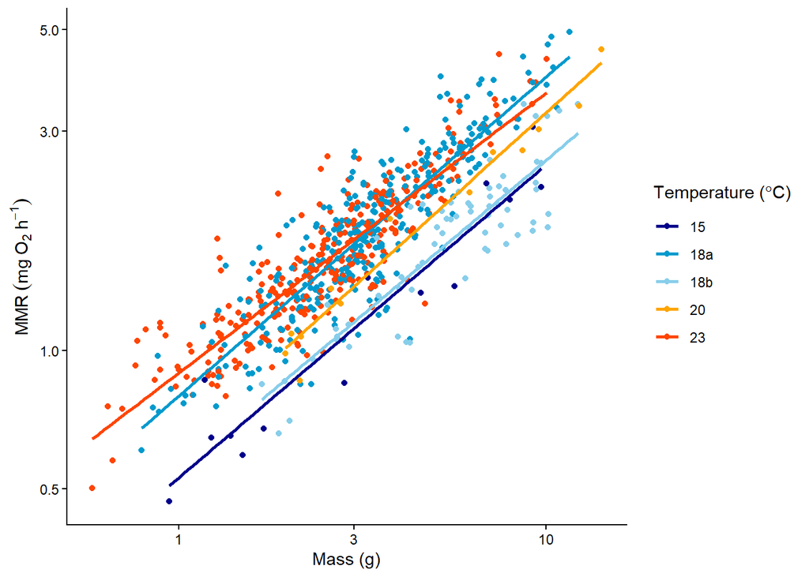

```r
fig2 <- ggplot(data = data, aes(x = mass, y = MMR, color = factor(Temp))) +
  geom_point() +
  geom_smooth(method = "lm", se = F) +
  theme_bw() +
  scale_color_manual(values =c("darkblue", "deepskyblue3", "skyblue", "orange", "orangered")) +
  labs(x = "Mass (g)", y = expression(MMR~(mg~O[2]~h^-1)), color = expression("Temperature ("*degree*C*")")) +
  scale_x_log10() +
  scale_y_log10() +
  theme_classic()

fig2
```

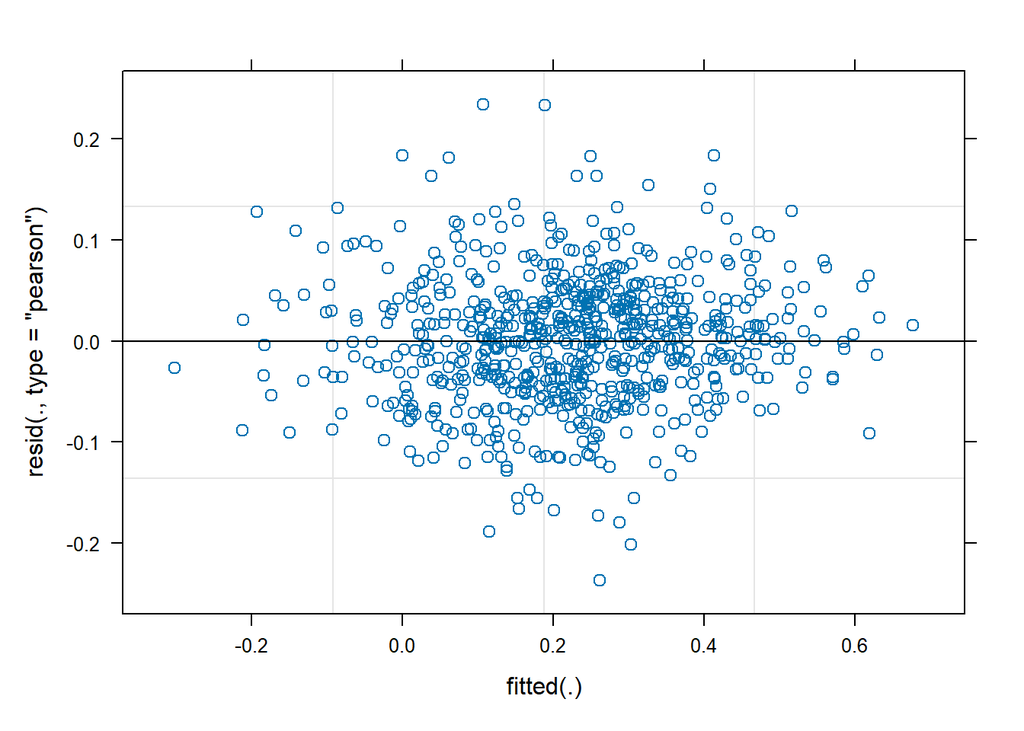

```r
lm_MMR <- lmer(log10(MMR) ~ log_mass*factor(Temp) + (1|ID), data = data)

#check assumptions
plot(lm_MMR)
```

```r
summary(lm_MMR)
```

```
## Linear mixed model fit by REML. t-tests use Satterthwaite's method [
## lmerModLmerTest]
## Formula: log10(MMR) ~ log_mass * factor(Temp) + (1 | ID)
##    Data: data
##
## REML criterion at convergence: -1652.3
##
## Scaled residuals:
##     Min      1Q  Median      3Q     Max
## -3.5077 -0.5845  0.0263  0.5743  3.4663
##
## Random effects:
##  Groups   Name        Variance Std.Dev.
##  ID       (Intercept) 0.001297 0.03602
##  Residual             0.004571 0.06761
## Number of obs: 720, groups:  ID, 199
##
## Fixed effects:
##                           Estimate Std. Error        df t value Pr(>|t|)
## (Intercept)               -0.27646    0.03456 597.13548  -8.000 6.50e-15 ***
## log_mass                   0.68072    0.05783 597.13547  11.771  < 2e-16 ***
## factor(Temp)18a            0.17423    0.03660 585.05754   4.760 2.44e-06 ***
## factor(Temp)18b            0.02076    0.05061 505.22938   0.410    0.682
## factor(Temp)20             0.07208    0.06028 597.13547   1.196    0.232
## factor(Temp)23             0.23039    0.03609 575.07233   6.384 3.57e-10 ***
## log_mass:factor(Temp)18a   0.02023    0.06159 599.58483   0.329    0.743
## log_mass:factor(Temp)18b  -0.01275    0.07524 530.96613  -0.169    0.866
## log_mass:factor(Temp)20    0.04109    0.08945 597.13547   0.459    0.646
## log_mass:factor(Temp)23   -0.07738    0.06160 591.18611  -1.256    0.210
## ---
## Signif. codes:  0 '***' 0.001 '**' 0.01 '*' 0.05 '.' 0.1 ' ' 1
##
## Correlation of Fixed Effects:
##                     (Intr) lg_mss factr(Tmp)18 fctr(Tmp)18b f(T)20 f(T)23
## log_mass            -0.806
## factr(Tmp)18        -0.944  0.761
## fctr(Tmp)18b        -0.683  0.550  0.645
## fctr(Tmp)20         -0.573  0.462  0.541        0.391
## fctr(Tmp)23         -0.958  0.771  0.904        0.654        0.549
## log_mss:fctr(Tmp)18  0.756 -0.939 -0.814       -0.516       -0.434 -0.724
## lg_mss:fctr(Tmp)18b  0.619 -0.769 -0.585       -0.871       -0.355 -0.593
## lg_ms:(T)20          0.521 -0.647 -0.492       -0.356       -0.867 -0.499
## lg_ms:(T)23          0.756 -0.939 -0.714       -0.516       -0.434 -0.806
##                     log_mss:fctr(Tmp)18 lg_mss:fctr(Tmp)18b l_:(T)20
## log_mass
## factr(Tmp)18
## fctr(Tmp)18b
## fctr(Tmp)20
## fctr(Tmp)23
## log_mss:fctr(Tmp)18
## lg_mss:fctr(Tmp)18b  0.722
## lg_ms:(T)20          0.607               0.497
## lg_ms:(T)23          0.881               0.722               0.607
```

```r
#compare slopes of metabolism-mass scaling at different temperatures
lm_MMR.compare <- emmeans::lstrends(lm_MMR, ~ Temp, var = "log_mass")

lm_MMR.slope <- cld(lm_MMR.compare)
lm_MMR.slope
```

```
##  Temp log_mass.trend     SE  df lower.CL upper.CL .group
##  23            0.603 0.0213 557    0.561    0.645  1
##  18b           0.668 0.0482 451    0.573    0.763  12
##  15            0.681 0.0578 605    0.567    0.794  12
##  18a           0.701 0.0213 624    0.659    0.743   2
##  20            0.722 0.0682 605    0.588    0.856  12
##
## Degrees-of-freedom method: kenward-roger
## Confidence level used: 0.95
## P value adjustment: tukey method for comparing a family of 5 estimates
## significance level used: alpha = 0.05
## NOTE: If two or more means share the same grouping symbol,
##       then we cannot show them to be different.
##       But we also did not show them to be the same.
```

```r
#now compare intercepts (at grand mean mass, not log_mass = 0) of metabolism-mass scaling at different temperatures
lm_MMR.int.compare <- emmeans(lm_MMR, ~Temp, at = list(log_mass = log10(mean(data$mass))))

lm_MMR.int <- cld(lm_MMR.int.compare)
lm_MMR.int
```

```
##  Temp emmean      SE  df lower.CL upper.CL .group
##  15    0.102 0.02090 605   0.0612    0.143  1
##  18b   0.116 0.01360 387   0.0893    0.143  1
##  20    0.197 0.02160 605   0.1548    0.240   2
##  18a   0.288 0.00586 157   0.2762    0.299    3
##  23    0.290 0.00682 183   0.2762    0.303    3
##
## Degrees-of-freedom method: kenward-roger
## Results are given on the log10 (not the response) scale.
## Confidence level used: 0.95
## P value adjustment: tukey method for comparing a family of 5 estimates
## significance level used: alpha = 0.05
## NOTE: If two or more means share the same grouping symbol,
##       then we cannot show them to be different.
##       But we also did not show them to be the same.
```

```r
MMR_ints <- lm_MMR.int %>%
  mutate(
    pwr_emmean = 10^(emmean),
    pwr_lower = 10^(lower.CL),
    pwr_upper = 10^(upper.CL))

MMR_ints
```

```
##   Temp    emmean          SE       df   lower.CL  upper.CL .group pwr_emmean
## 1   15 0.1023003 0.020928883 605.3661 0.06119828 0.1434023    1     1.265611
## 3  18b 0.1159679 0.013561720 387.4090 0.08930416 0.1426317    1     1.306074
## 4   20 0.1972411 0.021629120 605.3661 0.15476388 0.2397183     2    1.574857
## 2  18a 0.2877937 0.005855847 156.9063 0.27622726 0.2993602      3   1.939964
## 5   23 0.2896321 0.006821208 182.8904 0.27617369 0.3030904      3   1.948193
##   pwr_lower pwr_upper
## 1  1.151326  1.391241
## 3  1.228299  1.388774
## 4  1.428117  1.736674
## 2  1.888980  1.992325
## 5  1.888747  2.009511
```

#### Linear regression through SGR and SMR, by temp and time interval

Moving on, we are interested to understand whether SMR is influenced by growth rate. We start by making sure that our growth (SGR) data are mass-standardized:

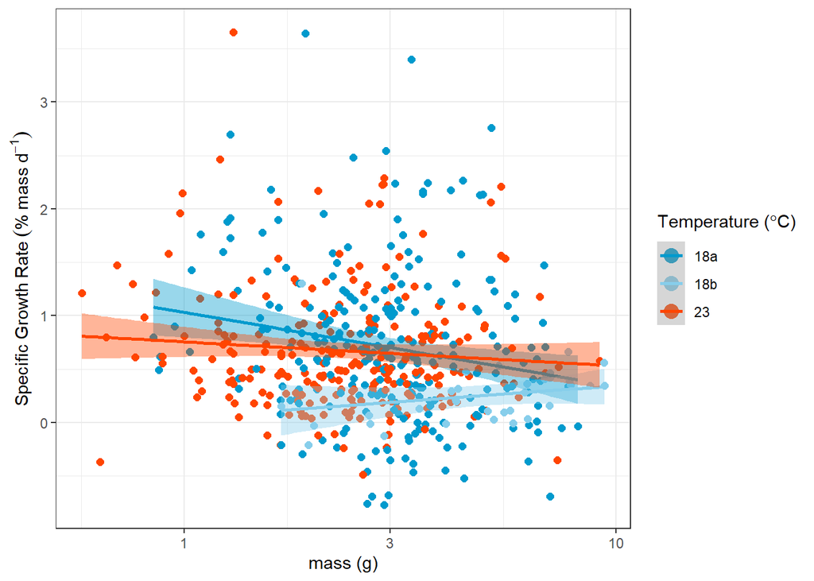

```
## [1] -0.1461605
```

```
## [1] -0.1692685
```

```
## [1] 0.2875297
```

```
## [1] -0.0519655
```

```
##
## Call:
## lm(formula = SGR_2m ~ mass * Temp, data = data_sgr)
##
## Residuals:
##      Min       1Q   Median       3Q      Max
## -1.51517 -0.40588 -0.09945  0.26986  2.94782
##
## Coefficients:
##              Estimate Std. Error t value Pr(>|t|)
## (Intercept)   0.98302    0.09860   9.970  < 2e-16 ***
## mass         -0.08464    0.02775  -3.050  0.00240 **
## Temp18b      -0.92822    0.30815  -3.012  0.00272 **
## Temp23       -0.25008    0.13370  -1.870  0.06199 .
## mass:Temp18b  0.12161    0.05815   2.091  0.03698 *
## mass:Temp23   0.06225    0.04148   1.500  0.13410
## ---
## Signif. codes:  0 '***' 0.001 '**' 0.01 '*' 0.05 '.' 0.1 ' ' 1
##
## Residual standard error: 0.6348 on 516 degrees of freedom
## Multiple R-squared:  0.04806,    Adjusted R-squared:  0.03884
## F-statistic: 5.211 on 5 and 516 DF,  p-value: 0.000112
```

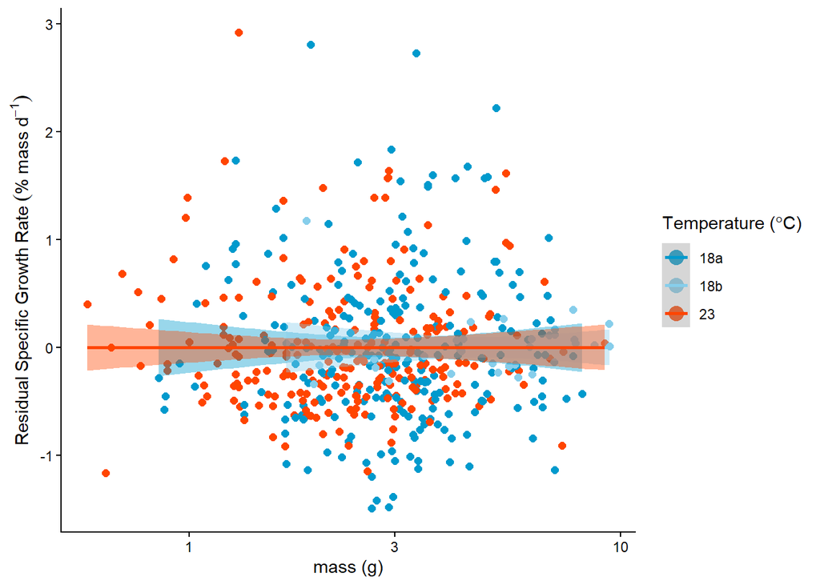

```
##
## Call:
## lm(formula = SGR_2m_resid ~ mass * factor(Temp), data = data_sgr)
##
## Residuals:
##      Min       1Q   Median       3Q      Max
## -1.49346 -0.40222 -0.09554  0.26989  2.93664
##
## Coefficients:
##                       Estimate Std. Error t value Pr(>|t|)
## (Intercept)          -0.013692   0.098332  -0.139    0.889
## mass                  0.004228   0.027675   0.153    0.879
## factor(Temp)18b      -0.036662   0.307324  -0.119    0.905
## factor(Temp)23       -0.017784   0.133342  -0.133    0.894
## mass:factor(Temp)18b  0.005270   0.057991   0.091    0.928
## mass:factor(Temp)23   0.007815   0.041373   0.189    0.850
##
## Residual standard error: 0.6331 on 516 degrees of freedom
## Multiple R-squared:  0.0004095,  Adjusted R-squared:  -0.009276
## F-statistic: 0.04228 on 5 and 516 DF,  p-value: 0.999
```

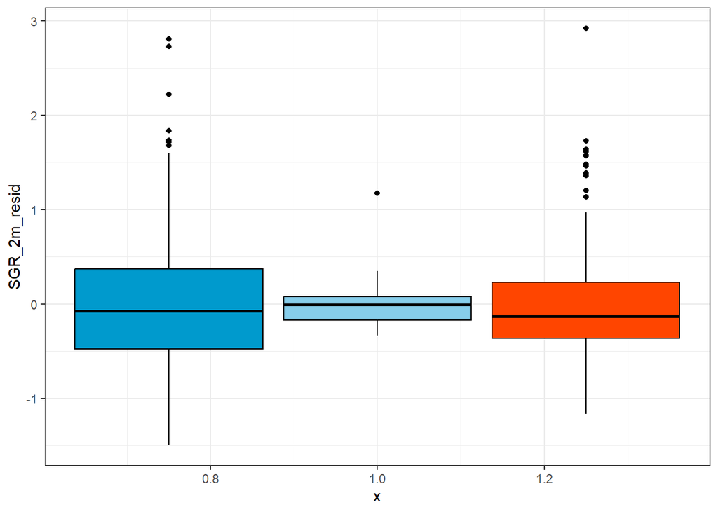